# Modeling MasterControl

Author

Josh, Joel, Corinn, Gaby

Published

February 28, 2026

# Introduction

This notebook builds an initial model to help identify which Mx leads are more likely to be successful. Using the cleaned dataset from the EDA phase, the goal is to better understand which lead characteristics are associated with progression to SQL, SQO, or Won, so Marketing and Sales can target higher potential leads more effectively.

### Load Data

In this section, we load the cleaned modeling-ready dataset,`leads_cleaned_final.rds` that was created during the EDA phase. This gives us a consistent starting point for modeling and allows the notebook to focus on prediction without repeating all of the earlier data cleaning steps.

# Create Modeling Dataset

In this section, we prepare the final dataset that will be used for modeling. Because the business problem is focused on Mx targeting, we keep only Mx leads, remove fields that should not be used as predictors, and make sure the target variable is labeled clearly for interpretation.

```r
# Keep Mx leads only and remove IDs + original outcome
mx_model_data <- leads_cleaned_final %>%
  filter(solution_rollup == "Mx") %>%
  select(-qal_id, -contact_lead_id, -next_stage_c)

# Drop leftover duplicate column if present
if ("solution.1" %in% names(mx_model_data)) {
  mx_model_data <- mx_model_data %>%
    select(-solution.1)
}

# Relabel target for readability
mx_model_data <- mx_model_data %>%
  mutate(
    next_stage_target = factor(
      next_stage_target,
      levels = c("0", "1"),
      labels = c("Not Successful", "Successful")
    )
  )

# Quick checks
dim(mx_model_data)
```

```
[1] 4081  419
```

```r
count(mx_model_data, next_stage_target)
```

```
  next_stage_target    n
1    Not Successful 3552
2        Successful  529
```

```r
"solution.1" %in% names(mx_model_data)
```

```
[1] FALSE
```

### Interpretation of Output

The modeling dataset now includes only Mx leads, since that is the product line this project is focused on. After removing ID fields, the original outcome column, and the leftover duplicate column, the final Mx modeling dataset contains 4,081 rows and 419 columns.

The target variable is also clearly imbalanced. Out of the 4,081 Mx leads, 3,552 were not successful and 529 were successful, where successful means the lead progressed to SQL, SQO, or Won. This means only about 13.0% of MX leads reached a successful outcome.

From a business perspective, this tells us that successful Mx leads are relatively uncommon, which is consistent with what we found in the EDA. For the marketing team, this is important because it confirms that the current pool of Mx leads contains many more low converting leads than high converting ones. Because of that, the goal of modeling is not just to predict the majority group, but to help identify the smaller group of leads with a higher chance of success so targeting can be improved.

# Train/Test Split

The next step is to split the Mx dataset into a training set and a test set. The training set will be used to build the model, and the test set will be used later to check how well the model performs on new data. We use a 70/30 split, and we keep the success rate similar in both groups so the comparison is fair.

```r
# Create 70/30 train/test split while keeping target balance similar
set.seed(123)

# Create split index
split_index <- createDataPartition(
  y = mx_model_data$next_stage_target,
  p = 0.70,
  list = FALSE
)

# Create training and test datasets
mx_training_data <- mx_model_data[split_index, ]
mx_test_data <- mx_model_data[-split_index, ]

# Quick checks
dim(mx_training_data)
```

```
[1] 2858  419
```

```r
dim(mx_test_data)
```

```
[1] 1223  419
```

```r
# Class balance by dataset
bind_rows(
  mx_training_data %>% mutate(dataset = "Training Set"),
  mx_test_data %>% mutate(dataset = "Test Set")
) %>%
  count(dataset, next_stage_target)
```

```
       dataset next_stage_target    n
1     Test Set    Not Successful 1065
2     Test Set        Successful  158
3 Training Set    Not Successful 2487
4 Training Set        Successful  371
```

### Interpretation of Output

The balance of successful and not successful leads stayed very similar in both groups. In the training set, 2,487 leads were not successful and 371 were successful, while in the test set, 1,065 leads were not successful and 158 were successful. This is important because it means both datasets reflect the same overall success pattern, giving us a fairer and more reliable way to evaluate whether the model can help identify higher-potential Mx leads.

# Performance Benchmark

For this project, a useful model should perform better than random guessing and should show a meaningful ability to separate higher-potential Mx leads from lower-potential ones. Because the target variable is imbalanced, ROC AUC is one of the most important benchmark metrics. As an initial guideline, a model with ROC AUC around 0.70 or higher would suggest that the model is capturing useful predictive signal.

At the same time, business usefulness also matters. Even if the model is not perfect, it can still be valuable if it helps Marketing and Sales better prioritize leads that are more likely to progress to SQL, SQO, or Won compared with the current untargeted approach

# Modeling

## Baseline Model

In this section, we build a baseline model using logistic regression. This gives us a simple starting point for predicting whether an Mx lead will be successful. Starting with a baseline model is helpful because it gives us an initial benchmark that stronger models can later be compared against.

For this project, logistic regression is a good first choice because it is easier to interpret than more complex models. Since the business goal is to understand which lead characteristics, such as job title and industry, are associated with higher conversion, a baseline model helps us begin answering that question in a way that is still understandable for the business team.

```r
# Create cross-validation folds on the training data
set.seed(123)

mx_folds <- vfold_cv(
  mx_training_data,
  v = 5,
  strata = next_stage_target
)

# Create recipe for preprocessing
mx_recipe <- recipe(next_stage_target ~ ., data = mx_training_data) %>%
  step_rm(contact_lead_title) %>%
  step_novel(all_nominal_predictors()) %>%
  step_other(all_nominal_predictors(), threshold = 0.01) %>%
  step_dummy(all_nominal_predictors()) %>%
  step_zv(all_predictors())

# Define logistic regression model
mx_log_model <- logistic_reg() %>%
  set_engine("glm") %>%
  set_mode("classification")

# Build workflow
mx_log_workflow <- workflow() %>%
  add_recipe(mx_recipe) %>%
  add_model(mx_log_model)

# Fit model with cross-validation
mx_log_results <- fit_resamples(
  mx_log_workflow,
  resamples = mx_folds,
  metrics = metric_set(
    yardstick::roc_auc,
    yardstick::accuracy,
    yardstick::precision,
    yardstick::recall,
    yardstick::f_meas
  )
)

# View performance metrics
collect_metrics(mx_log_results)
```

```
# A tibble: 5 × 6
  .metric   .estimator  mean     n std_err .config
  <chr>     <chr>      <dbl> <int>   <dbl> <chr>
1 accuracy  binary     0.850     5 0.00222 pre0_mod0_post0
2 f_meas    binary     0.916     5 0.00128 pre0_mod0_post0
3 precision binary     0.895     5 0.00291 pre0_mod0_post0
4 recall    binary     0.937     5 0.00367 pre0_mod0_post0
5 roc_auc   binary     0.709     5 0.0152  pre0_mod0_post0
```

### Interpretation of Output

The baseline logistic regression model ran successfully and produced an initial set of performance metrics using 5-fold cross-validation on the training data. The model achieved an accuracy of 0.85 and a ROC AUC of 0.71. Because the target variable is imbalanced, ROC AUC is especially important here. A value of 0.71 suggests that the model has a reasonable ability to separate leads that are more likely to be successful from those that are less likely to be successful.

## Logistic Regression with Interaction combinations

Additional attempts were made to improve upon the initial logistic regression model using combinations of interactions. As interpretability is necessary, this exlcudes the use of more complex “black-box” methods, necessitating further exploration of simpler modeling options.

```r
# Data Prep
train_lr <- mx_training_data

train_lr$next_stage_target <- factor(train_lr$next_stage_target)
levels(train_lr$next_stage_target) <- gsub(" ", "_", levels(train_lr$next_stage_target))

# Case weights for imbalance
case_weights_lr <- ifelse(train_lr$next_stage_target == "Successful", 7, 1)

# CV Control
cv_control_lr <- trainControl(
  method          = "cv",
  number          = 5,
  classProbs      = TRUE,
  summaryFunction = twoClassSummary,
  savePredictions = "final",
  allowParallel   = TRUE,
  verboseIter     = TRUE
)

# --- Create interaction terms automatically ---
# model.matrix expands all factors AND creates pairwise interactions
# between your most important features from RF/XGB

top_features <- c("priority", "last_tactic_campaign_channel",
                  "acct_tier_rollup", "acct_primary_site_function",
                  "solution", "acct_territory_rollup")

# Create interaction matrix from top features only
train_interactions <- model.matrix(
  ~ .^2,
  data = dplyr::select(train_lr, all_of(top_features))
) %>%
  as.data.frame()


# Remove intercept column using base R indexing
train_interactions <- train_interactions[, colnames(train_interactions) != "(Intercept)"]

# Add back remaining non-interacted columns
remaining_cols <- dplyr::select(train_lr, -all_of(top_features), -next_stage_target)

train_lr_final <- bind_cols(train_interactions, remaining_cols) %>%
  mutate(next_stage_target = train_lr$next_stage_target)

cat(sprintf("Columns after interactions: %d\n", ncol(train_lr_final)))
```

```
Columns after interactions: 4489
```

```r
# --- Grid Search (glmnet = regularized logistic regression) ---
lr_grid <- expand.grid(
  alpha  = c(0, 0.5, 1),     # 0 = Ridge, 1 = Lasso, 0.5 = ElasticNet
  lambda = c(0.001, 0.01, 0.1, 1)  # Regularization strength
)

# --- Train ---
lr_model <- train(
  next_stage_target ~ .,
  data      = train_lr_final,
  method    = "glmnet",
  metric    = "ROC",
  trControl = cv_control_lr,
  tuneGrid  = lr_grid,
  weights   = case_weights_lr,
  family    = "binomial"
)
cat("\n--- CV Results (top 5 by ROC) ---\n")
```

```
--- CV Results (top 5 by ROC) ---
```

```r
lr_model$results %>% arrange(desc(ROC)) %>% head(5) %>% print()
```

```
  alpha lambda       ROC      Sens      Spec      ROCSD     SensSD     SpecSD
1     0  0.001 0.7944184 0.7921327 0.6552793 0.01542750 0.01858122 0.07078437
2     0  0.010 0.7944184 0.7921327 0.6552793 0.01542750 0.01858122 0.07078437
3     0  0.100 0.7944184 0.7921327 0.6552793 0.01542750 0.01858122 0.07078437
4     0  1.000 0.7944184 0.7921327 0.6552793 0.01542750 0.01858122 0.07078437
5     1  0.010 0.7919968 0.8154315 0.6093694 0.01327671 0.01923233 0.05082151
```

### Interpretation of Output

The top model outputs an improved **ROC AUC of .794** . The top performing combinations of hyper parameter values all outperform the previous model which is to be expected. Not a lot of detail will be given at this point on the results as future models are likely to out perform regression models.

## Decision Tree

In this section, a decision tree model is used as a second approach to predict Mx lead success. Unlike logistic regression, a decision tree can capture nonlinear patterns and interactions more naturally, while also producing simpler rules that are easier to explain to a business audience.

This is especially useful for this project because the goal is not only to predict success, but also to better understand which types of leads should be prioritized. A decision tree can help translate the data into more practical decision rules around variables such as industry, enrichment quality, and title-related signals.

```r
# Define decision tree model spec with tunable parameters
mx_dt_model <- decision_tree(
  cost_complexity  = tune(),
  tree_depth       = tune(),
  min_n            = tune()
) %>%
  set_engine("rpart") %>%
  set_mode("classification")

# Build workflow using same recipe as baseline
mx_dt_workflow <- workflow() %>%
  add_recipe(mx_recipe) %>%
  add_model(mx_dt_model)
# Define tuning grid
dt_grid <- grid_regular(
  cost_complexity(range = c(-4, -1)),
  tree_depth(range      = c(3, 10)),
  min_n(range          = c(5, 50)),
  levels = 4
)

# Tune over 5-fold CV folds (reuse mx_folds from baseline)
set.seed(123)

mx_dt_tune <- tune_grid(
  mx_dt_workflow,
  resamples = mx_folds,
  grid      = dt_grid,
  metrics   = metric_set(
    yardstick::roc_auc,
    yardstick::accuracy,
    yardstick::f_meas
  )
)

# Show top 5 configurations ranked by ROC AUC
mx_dt_tune %>%
  show_best(metric = "roc_auc", n = 5)
```

```
# A tibble: 5 × 9
  cost_complexity tree_depth min_n .metric .estimator  mean     n std_err
            <dbl>      <int> <int> <chr>   <chr>      <dbl> <int>   <dbl>
1          0.0001          5    20 roc_auc binary     0.758     5 0.00425
2          0.001           5    20 roc_auc binary     0.758     5 0.00425
3          0.0001         10    20 roc_auc binary     0.758     5 0.00483
4          0.001          10    20 roc_auc binary     0.758     5 0.00483
5          0.0001          7    20 roc_auc binary     0.758     5 0.00558
# ℹ 1 more variable: .config <chr>
```

```r
# Select the best configuration and finalize workflow
best_dt_params <- select_best(mx_dt_tune, metric = "roc_auc")

mx_dt_final_workflow <- finalize_workflow(mx_dt_workflow, best_dt_params)

# Fit finalized model on full training set
mx_dt_final_fit <- mx_dt_final_workflow %>%
  fit(data = mx_training_data)

# View final hyperparameters
best_dt_params
```

```
# A tibble: 1 × 4
  cost_complexity tree_depth min_n .config
            <dbl>      <int> <int> <chr>
1          0.0001          5    20 pre0_mod06_post0
```

```r
# Evaluate on cross-validation
mx_dt_cv_results <- fit_resamples(
  mx_dt_final_workflow,
  resamples = mx_folds,
  metrics   = metric_set(
    yardstick::roc_auc,
    yardstick::accuracy,
    yardstick::precision,
    yardstick::recall,
    yardstick::f_meas
  )
)

collect_metrics(mx_dt_cv_results)
```

```
# A tibble: 5 × 6
  .metric   .estimator  mean     n std_err .config
  <chr>     <chr>      <dbl> <int>   <dbl> <chr>
1 accuracy  binary     0.871     5 0.00359 pre0_mod0_post0
2 f_meas    binary     0.930     5 0.00209 pre0_mod0_post0
3 precision binary     0.883     5 0.00241 pre0_mod0_post0
4 recall    binary     0.982     5 0.00525 pre0_mod0_post0
5 roc_auc   binary     0.758     5 0.00425 pre0_mod0_post0
```

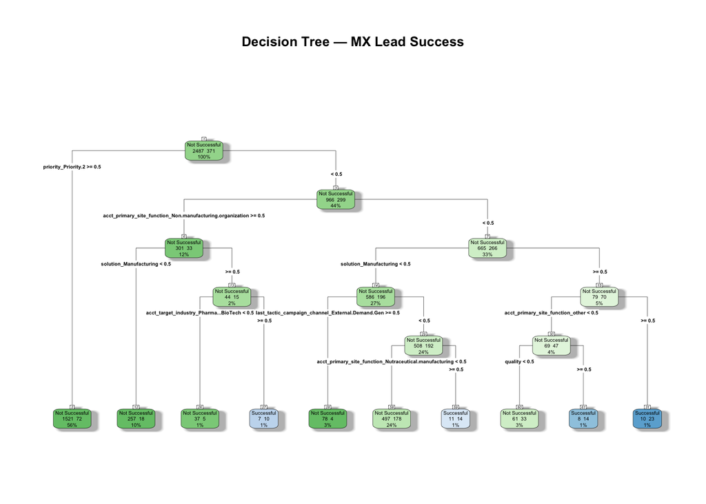

```r
# Extract the underlying rpart tree object for visualization
dt_rpart_fit <- mx_dt_final_fit %>%
  extract_fit_engine()

# Plot the decision tree (base rpart plot)
rpart.plot(
  dt_rpart_fit,
  type       = 4,
  extra      = 101,
  box.palette = "GnBu",
  shadow.col = "gray",
  nn         = TRUE,
  main       = "Decision Tree — MX Lead Success"
)
```

```r
# Extract variable importance from the fitted tree
dt_importance <- dt_rpart_fit$variable.importance %>%
  enframe(name = "feature", value = "importance") %>%
  arrange(desc(importance)) %>%
  slice_head(n = 15)
```

## Random Forest Model

In this section a random forest model is trained, using both over sampled data and data matching the default class imbalance.

### OverSampled

Oversampling was used to get the data to a 50/50 class balance split. Then grid search and 5 fold cross validation was used. This process was run iteritavely to test and try and avoid overfitting.

```r
#drop qal cohort date
mx_training_data <- mx_training_data %>% select(-qal_cohort_date)
mx_test_data <- mx_test_data %>% select(-qal_cohort_date)
```

```r
#create 50/50 data split
train_balanced <- upSample(
  x = mx_training_data %>% select(-next_stage_target),
  y = mx_training_data$next_stage_target,
  yname = "next_stage_target"
)

train_balanced <- train_balanced %>% select(-contact_lead_title)
train_balanced$next_stage_target <-factor(train_balanced$next_stage_target)
levels(train_balanced$next_stage_target) <- gsub(" ", "_", levels(train_balanced$next_stage_target))
```

```r
#define cv params
cv_control <- trainControl(
  method          = "cv",
  number          = 5,
  classProbs      = TRUE,           # Needed for ROC/AUC
  summaryFunction = twoClassSummary, # Reports ROC, Sens, Spec
  savePredictions = "final",
  allowParallel   = TRUE,
  verboseIter     = TRUE
)

#define grid search params
#rf_grid <- expand.grid(
 # mtry            = c(10, 20, 30, floor(sqrt(ncol(train_balanced) - 1))),
  #splitrule       = c("gini", "extratrees"),
  #min.node.size   = c(1, 5, 10)
#)

#for brevity on fileouptut best performing is hard coded
rf_grid <- expand.grid(
  mtry            = 30,
  splitrule       = "gini",
  min.node.size   = c(50)
)
```

```r
#train rf model
rf_model <- train(
  next_stage_target ~ .,
  data       = train_balanced,
  method     = "ranger",
  metric     = "ROC",              # Optimise on AUC (better for imbalanced)
  trControl  = cv_control,
  tuneGrid   = rf_grid,
  num.trees  = 500,
  importance = "permutation"       # Required for variable importance
)
```

```r
cat("\n--- Best Hyperparameters ---\n")
```

```
--- Best Hyperparameters ---
```

```r
print(rf_model$bestTune)
```

```
  mtry splitrule min.node.size
1   30      gini            50
```

```r
cat("\n--- CV Results (top 5 by ROC) ---\n")
```

```
--- CV Results (top 5 by ROC) ---
```

```r
cv_results <- rf_model$results %>%
  arrange(desc(ROC)) %>%
  head(6)
print(cv_results)
```

```
  mtry splitrule min.node.size       ROC      Sens      Spec       ROCSD
1   30      gini            50 0.9595561 0.8355264 0.9453153 0.004737555
      SensSD     SpecSD
1 0.02215849 0.01492344
```

```r
#tree overfitting
```

```r
importance_df <- varImp(rf_model)$importance %>%
  rownames_to_column("Feature") %>%
  rename(Importance = Overall) %>%
  arrange(desc(Importance)) %>%
  head(50)

print(importance_df)
```

```
                                                      Feature Importance
1                                          priorityPriority 2 100.000000
2             last_tactic_campaign_channelExternal Demand Gen  46.115187
3                                          priorityPriority 1  41.348124
4                           last_tactic_campaign_channelEmail  35.092715
5    acct_primary_site_functionNon-manufacturing organization  32.935775
6                                       solutionManufacturing  25.276620
7                             last_tactic_campaign_channelSEO  22.960333
8                                     priorityP1 - Contact Us  20.267248
9                  last_tactic_campaign_channelDirect/Inbound  19.794451
10                        acct_territory_rollupAPAC & Oceania  16.268518
11                                          title_lowinfoTRUE  16.016592
12                                      acct_tier_rollupSmall  15.468093
13                           acct_manufacturing_modelIn-House  15.292296
14                                      acct_tier_rollupLarge  15.068178
```

[output cut: 36 more lines]

```r
# Fix test data factor levels
mx_test_data$next_stage_target <- factor(mx_test_data$next_stage_target)
levels(mx_test_data$next_stage_target) <- gsub(" ", "_", levels(mx_test_data$next_stage_target))

# Use caret's predict wrapper — handles encoding internally
test_probs <- predict(rf_model, newdata = mx_test_data, type = "prob")[, "Successful"]

test_preds <- predict(rf_model, newdata = mx_test_data)

# Evaluate
cm <- confusionMatrix(test_preds, mx_test_data$next_stage_target, positive = "Successful")
print(cm)
```

```
Confusion Matrix and Statistics

                Reference
Prediction       Not_Successful Successful
  Not_Successful            887         64
  Successful                178         94

               Accuracy : 0.8021
                 95% CI : (0.7787, 0.8241)
    No Information Rate : 0.8708
    P-Value [Acc > NIR] : 1

                  Kappa : 0.3273

 Mcnemar's Test P-Value : 3.76e-13

            Sensitivity : 0.59494
            Specificity : 0.83286
         Pos Pred Value : 0.34559
         Neg Pred Value : 0.93270
             Prevalence : 0.12919
         Detection Rate : 0.07686
   Detection Prevalence : 0.22240
      Balanced Accuracy : 0.71390

       'Positive' Class : Successful
```

```r
cat(sprintf("\nTest AUC: %.4f\n", auc(roc(mx_test_data$next_stage_target, test_probs,
                                          levels = c("Not_Successful", "Successful")))))
```

```
Test AUC: 0.8203
```

#### Interpretation of Output

When attempting to use random forest with over sampled data to achieve a 50/50 class balance split, the cross validation and grid search always found the smallest number of terminal nodes to be the best. Initially the cross validation ROC-AUC was unreasonably high, so holdout data was used to verify that in fact the data was over fitting. When running on test data though every time their was a substantial drop off in AUC indicating over fitting, even when trying higher values of terminal nodes.The models all coalesced around AUC of .82 to .83 previous models. Testing this model to confirm it was over fitting did require using the holdout data which would constitute data leakage, given this and the tendency to over fit while not having great performance random forest appears to not be a good fit for this data.

### Standard Class Distribution

```r
# Use original training data with class weights instead of oversampling
train_balanced <- mx_training_data %>%
  select(-contact_lead_title)

train_balanced$next_stage_target <- factor(train_balanced$next_stage_target)
levels(train_balanced$next_stage_target) <- gsub(" ", "_", levels(train_balanced$next_stage_target))
```

```r
#define cv params
cv_control <- trainControl(
  method          = "cv",
  number          = 5,
  classProbs      = TRUE,           # Needed for ROC/AUC
  summaryFunction = twoClassSummary, # Reports ROC, Sens, Spec
  savePredictions = "final",
  allowParallel   = TRUE,
  verboseIter     = TRUE
)

#define grid search params
#rf_grid <- expand.grid(
 # mtry            = c(10, 20, 30, floor(sqrt(ncol(train_balanced) - 1))),
  #splitrule       = c("gini", "extratrees"),
  #min.node.size   = c(1, 5, 10)
#)

# best values for brevity
rf_grid <- expand.grid(
  mtry            = c(20),
  splitrule       = "gini",
  min.node.size   = c(10)
)
```

```r
# Calculate per-row weights based on class
case_weights <- ifelse(train_balanced$next_stage_target == "Successful", 7, 1)


rf_model <- train(
  next_stage_target ~ .,
  data       = train_balanced,
  method     = "ranger",
  metric     = "ROC",
  trControl  = cv_control,
  tuneGrid   = rf_grid,
  num.trees  = 500,
  importance = "permutation",
  weights = case_weights
)
```

```r
cat("\n--- Best Hyperparameters ---\n")
```

```
--- Best Hyperparameters ---
```

```r
print(rf_model$bestTune)
```

```
  mtry splitrule min.node.size
1   20      gini            10
```

```r
cat("\n--- CV Results (top 5 by ROC) ---\n")
```

```
--- CV Results (top 5 by ROC) ---
```

```r
cv_results <- rf_model$results %>%
  arrange(desc(ROC)) %>%
  head(6)
print(cv_results)
```

```
  mtry splitrule min.node.size       ROC     Sens      Spec      ROCSD
1   20      gini            10 0.8185754 0.827108 0.6441802 0.01892073
      SensSD     SpecSD
1 0.01760387 0.04945534
```

```r
#tree overfitting
```

#### Interpretation of Output

When attempting to provide grid search parameters that would avoid overfitting ROC-AUC dropped substantially, and perfomed even worse then the prior trained model. Given the points discussed before it can be concluded that random forest is not a good fit for this data.

## XG Boost

A standard XGBoost model was trained, given XGBoost lacks interpretability this model is evaluated and will be contrasted with Explainable Boosting Machine next, which performs similar modeling but by design allows for explainability. If XGBoost has markedly better perofrmance over EBM, future steps will be taken to help explain the model decisions.

```r
# XGBoost version — matching your existing RF pipeline


# --- Data Prep (no oversampling — use weights like RF v2) ---
train_xgb <- mx_training_data %>% select(-contact_lead_title)
train_xgb$next_stage_target <- factor(train_xgb$next_stage_target)
levels(train_xgb$next_stage_target) <- gsub(" ", "_", levels(train_xgb$next_stage_target))

# Case weights for imbalance
case_weights_xgb <- ifelse(train_xgb$next_stage_target == "Successful", 7, 1)

# --- CV Control (identical to RF) ---
cv_control_xgb <- trainControl(
  method          = "cv",
  number          = 5,
  classProbs      = TRUE,
  summaryFunction = twoClassSummary,
  savePredictions = "final",
  allowParallel   = TRUE,
  verboseIter     = TRUE
)

# --- Grid Search ---
xgb_grid <- expand.grid(
  nrounds          = 500,   # Number of trees
  max_depth        = 6,            # Tree depth — keep shallow vs RF
  eta              = 0.01,       # Learning rate
  gamma            = 0,                  # Min loss reduction to split
  colsample_bytree = 0.7,        # Fraction of cols per tree (like mtry)
  min_child_weight = 5,            # Like min.node.size
  subsample        = 0.8                 # Row sampling per tree
)

# --- Grid Search ---
#xgb_grid <- expand.grid(
 # nrounds          = c(100,250,500),   # Number of trees
  #max_depth        = c(2,4,6),            # Tree depth — keep shallow vs RF
  #eta              = c(.1,0.01),       # Learning rate
  #gamma            = 0,                  # Min loss reduction to split
  #colsample_bytree = c(0.7,0.5)        # Fraction of cols per tree (like mtry)
  #min_child_weight = c(5,10,20)            # Like min.node.size
  #subsample        = c(0.7,0.8)                 # Row sampling per tree
#)

cat(sprintf("Grid search over %d combinations...\n", nrow(xgb_grid)))
```

```
Grid search over 1 combinations...
```

```r
# --- Train XGBoost ---
xgb_model <- train(
  next_stage_target ~ .,
  data        = train_xgb,
  method      = "xgbTree",
  metric      = "ROC",
  trControl   = cv_control_xgb,
  tuneGrid    = xgb_grid,
  weights     = case_weights_xgb,
  verbosity   = 0                        # Suppress xgb internal logs
)
```

```r
# Fix test data factor levels to match training
mx_test_data$next_stage_target <- factor(mx_test_data$next_stage_target)
levels(mx_test_data$next_stage_target) <- gsub(" ", "_", levels(mx_test_data$next_stage_target))

# Now run confusion matrix
#cm_xgb <- confusionMatrix(test_preds_xgb, mx_test_data$next_stage_target, positive = "Successful")
#print(cm_xgb)

#cat(sprintf("\nTest AUC: %.4f\n", pROC::auc(pROC::roc(mx_test_data$next_stage_target, test_probs_xgb,
                                                        #levels = c("Not_Successful", "Successful")))))
```

```r
# --- Best Hyperparameters ---
cat("\n--- Best Hyperparameters ---\n")
```

```
--- Best Hyperparameters ---
```

```r
print(xgb_model$bestTune)
```

```
  nrounds max_depth  eta gamma colsample_bytree min_child_weight subsample
1     500         6 0.01     0              0.7                5       0.8
```

```r
cat("\n--- CV Results (top 5 by ROC) ---\n")
```

```
--- CV Results (top 5 by ROC) ---
```

```r
cv_results_xgb <- xgb_model$results %>%
  arrange(desc(ROC)) %>%
  head(10)
print(cv_results_xgb)
```

```
  nrounds max_depth  eta gamma colsample_bytree min_child_weight subsample
1     500         6 0.01     0              0.7                5       0.8
       ROC     Sens      Spec    ROCSD    SensSD     SpecSD
1 0.810708 0.775224 0.7007207 0.018529 0.0118322 0.02530874
```

```r
# --- Feature Importance ---
importance_df_xgb <- varImp(xgb_model)$importance %>%
  rownames_to_column("Feature") %>%
  rename(Importance = Overall) %>%
  arrange(desc(Importance)) %>%
  head(5)
print(importance_df_xgb)
```

```
                                                   Feature Importance
1                                       priorityPriority 2  100.00000
2          last_tactic_campaign_channelExternal Demand Gen   34.87434
3 acct_primary_site_functionNon-manufacturing organization   24.53163
4                                        title_lowinfoTRUE   19.85951
5                        last_tactic_campaign_channelEmail   18.17121
```

```r
# --- Predict on Test Set ---
test_probs_xgb <- predict(xgb_model, newdata = mx_test_data, type = "prob")[, "Successful"]
test_preds_xgb <- predict(xgb_model, newdata = mx_test_data)

# --- Evaluate ---
cm_xgb <- confusionMatrix(test_preds_xgb, mx_test_data$next_stage_target, positive = "Successful")
print(cm_xgb)
```

```
Confusion Matrix and Statistics

                Reference
Prediction       Not_Successful Successful
  Not_Successful            808         36
  Successful                257        122

               Accuracy : 0.7604
                 95% CI : (0.7355, 0.7841)
    No Information Rate : 0.8708
    P-Value [Acc > NIR] : 1

                  Kappa : 0.3327

 Mcnemar's Test P-Value : <2e-16

            Sensitivity : 0.77215
            Specificity : 0.75869
         Pos Pred Value : 0.32190
         Neg Pred Value : 0.95735
             Prevalence : 0.12919
         Detection Rate : 0.09975
   Detection Prevalence : 0.30989
      Balanced Accuracy : 0.76542

       'Positive' Class : Successful
```

```r
cat(sprintf("\nTest AUC: %.4f\n", pROC::auc(pROC::roc(mx_test_data$next_stage_target, test_probs_xgb,
                                                        levels = c("Not_Successful", "Successful")))))
```

```
Test AUC: 0.8308
```

#### Interpretation of Output

This had similar performance to random forest with **AUC ROC of .82**, the model has a good balance of specificity being able to correctly identify 76% of leads that wouldn’t progress and sensitivity being able to correctly identify 77% of real successful leads. We can see the top feature importance, which tells us what the most important feature is and then a score for the next most important relative to that.

## Explainable Boosting Machine (EBM)

In this section, we fit an Explainable Boosting Machine (EBM) as a third modeling approach. EBMs are a type of Generalized Additive Model with pairwise interactions (GA²M) that use cyclic gradient boosting to learn shape functions for each feature. Unlike black-box models, EBMs are fully interpretable — each feature’s contribution can be visualized independently — while still achieving accuracy competitive with ensemble methods like random forests and gradient boosting.

EBMs are especially useful for this project because they can show exactly *how* each lead characteristic (industry, territory, title role, enrichment quality) relates to conversion probability, which directly supports the business goal of understanding what makes a strong Mx lead.

This section uses the `ebm` R package, which wraps the Python `interpret` library via `reticulate`. The EBM section is fully self-contained — it independently loads data, joins cluster labels from the EDA phase, and creates its own train/test split using the same seed and method as the shared pipeline to ensure identical row partitions.

```r
# Load cluster labels exported from EDA
cluster_labels    <- readRDS("data/cluster_labels.rds")
mx_cluster_labels <- readRDS("data/mx_cluster_labels.rds")

# Build EBM dataset independently — join cluster features, filter to Mx
ebm_data <- readRDS("data/leads_cleaned_final.rds") %>%
  left_join(cluster_labels, by = "qal_id") %>%
  left_join(mx_cluster_labels, by = "qal_id") %>%
  filter(solution_rollup == "Mx") %>%
  mutate(
    next_stage_target = factor(
      next_stage_target,
      levels = c("0", "1"),
      labels = c("Not Successful", "Successful")
    )
  ) %>%
  # Replace NAs in title_cluster with explicit level
  # (titles flagged as low-info were never clustered — EBM handles NAs
  #  internally but cannot display them in shape-function plots)
  mutate(
    title_cluster = fct_na_value_to_level(title_cluster, level = "No_Title_Info")
  ) %>%
  select(-qal_id, -contact_lead_id, -next_stage_c,
         -contact_lead_title, -solution_rollup)

# Drop leftover duplicate column if present
if ("solution.1" %in% names(ebm_data)) {
  ebm_data <- ebm_data %>% select(-solution.1)
}

# Same seed + stratified split as shared pipeline → identical row partition
set.seed(123)
ebm_split_idx <- caret::createDataPartition(
  y = ebm_data$next_stage_target, p = 0.70, list = FALSE
)
ebm_train <- ebm_data[ebm_split_idx, ]
ebm_test  <- ebm_data[-ebm_split_idx, ]

dim(ebm_train)
```

```
[1] 2858  420
```

```r
dim(ebm_test)
```

```
[1] 1223  420
```

### Interpretation of EBM Data Prep

The EBM dataset is built independently from the shared pipeline to avoid introducing cluster-label NAs into the existing GLM and decision tree recipes. Three engineered features from the EDA clustering phase — `account_cluster`, `title_cluster`, and `mx_cluster` — are joined onto the base modeling data. For `title_cluster`, rows where the lead title was flagged as low-info (and therefore never clustered) have their NA replaced with an explicit `"No_Title_Info"` factor level so that EBM can visualize the shape function for that group.

```r
# Fit Explainable Boosting Machine
mx_ebm <- ebm(next_stage_target ~ ., data = ebm_train, objective = "log_loss")
print(mx_ebm)
```

```
Call:
ebm(formula = next_stage_target ~ ., data = ebm_train, objective = "log_loss")

Python object:
ExplainableBoostingClassifier(early_stopping_tolerance=0,
                              interaction_smoothing_rounds=100,
                              interactions=0.9, learning_rate=0.04,
                              max_rounds=25000, min_hessian=0.0, n_jobs=-1,
                              outer_bags=16, smoothing_rounds=500)

Number of features: 419
Number of terms: 797
Number of interactions: 378
Intercept: -3.096
Objective: log_loss
Link function: logit
```

### Interpretation of EBM Fit

The `ebm()` call fits a GA²M model using cyclic gradient boosting. Each feature gets its own smooth shape function (main effect), and the model also automatically detects and fits the most important pairwise interaction terms. The `log_loss` objective is appropriate for binary classification — it optimizes the model to encourage well-calibrated predicted probabilities rather than just class labels.

The printed summary shows the number of main effects and interaction terms retained, along with the intercept. Unlike the GLM (which required dummy encoding via `step_dummy`) or the decision tree (which splits on one variable at a time), the EBM learns flexible nonlinear relationships for each feature while remaining fully interpretable.

```r
# Generate predictions on the held-out test set
ebm_probs  <- predict(mx_ebm, newdata = ebm_test)
ebm_labels <- predict(mx_ebm, newdata = ebm_test, type = "class")

# Confusion matrix
table("Observed" = ebm_test$next_stage_target, "Predicted" = ebm_labels)
```

```
                Predicted
Observed         Not Successful Successful
  Not Successful           1054         11
  Successful                 98         60
```

### Interpretation of EBM Predictions

The confusion matrix shows how the EBM classifies test-set leads compared to their actual outcomes. The key metrics to watch are:

- **True Positives (Successful predicted as Successful):** how many real successes the model catches
- **False Negatives (Successful predicted as Not Successful):** how many real successes the model misses
- **False Positives (Not Successful predicted as Successful):** leads the model incorrectly flags as promising

Because the target is imbalanced (~12.9% success rate), raw accuracy can be misleading — a model that predicts “Not Successful” for every lead would still be ~87% accurate. The calibration plot in the next section provides a better view of whether the predicted probabilities are reliable.

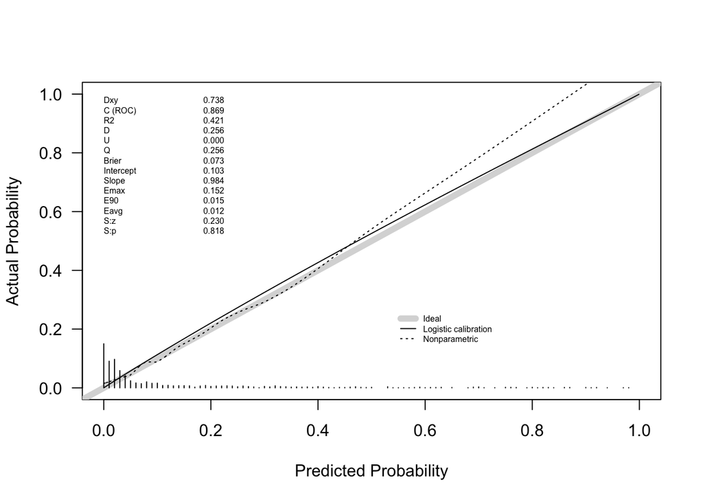

```
          Dxy       C (ROC)            R2             D      D:Chi-sq
  0.738218340   0.869109170   0.421174416   0.255501022 313.477749761
          D:p             U      U:Chi-sq           U:p             Q
  0.000000000  -0.000440833   1.460861271   0.481701508   0.255941855
        Brier     Intercept         Slope          Emax           E90
  0.072574217   0.102961243   0.984429320   0.152103518   0.014557521
         Eavg           S:z           S:p
  0.012066664   0.230450007   0.817742107
```

```r
library(rms)
# Calibration plot: predicted probability vs observed frequency
par(las = 1)
rms::val.prob(
  ebm_probs[, 2L],
  as.integer(ebm_test$next_stage_target == "Successful"),
  cex = 0.5
)
```

### Interpretation of EBM Calibration

The calibration plot compares the model’s predicted probabilities against the actual observed success rates. A well-calibrated model should have points falling close to the 45-degree diagonal line — meaning that when the model says a lead has a 20% chance of success, roughly 20% of those leads actually succeed.

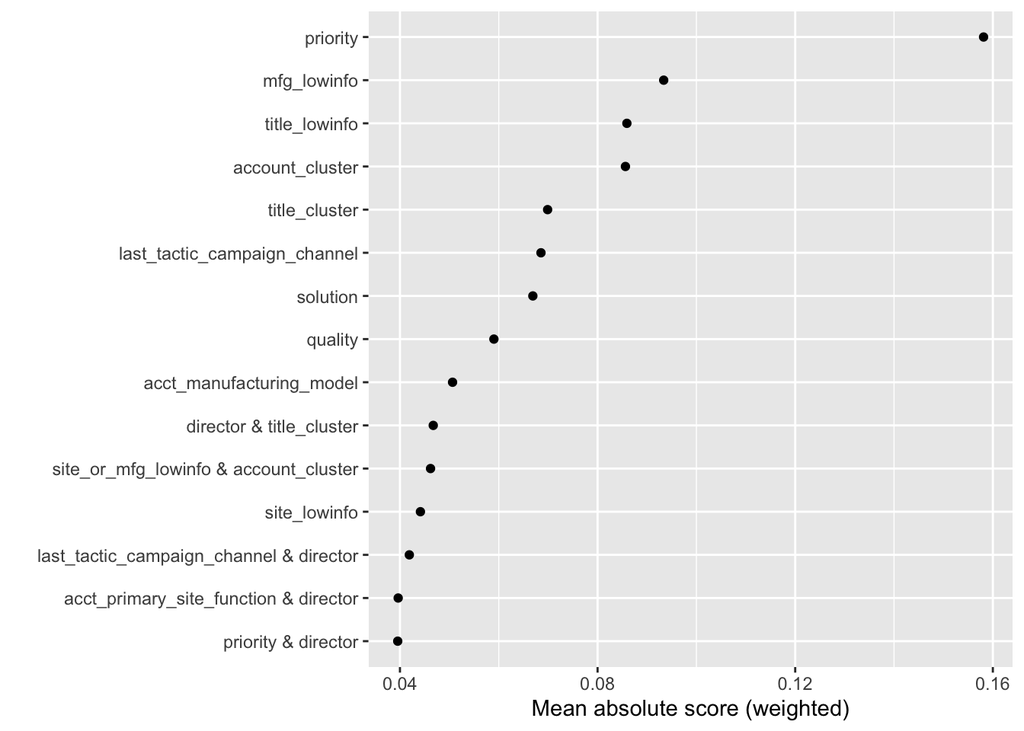

```r
# Top 15 most important terms (main effects + interactions)
plot(mx_ebm, n_terms = 15)
```

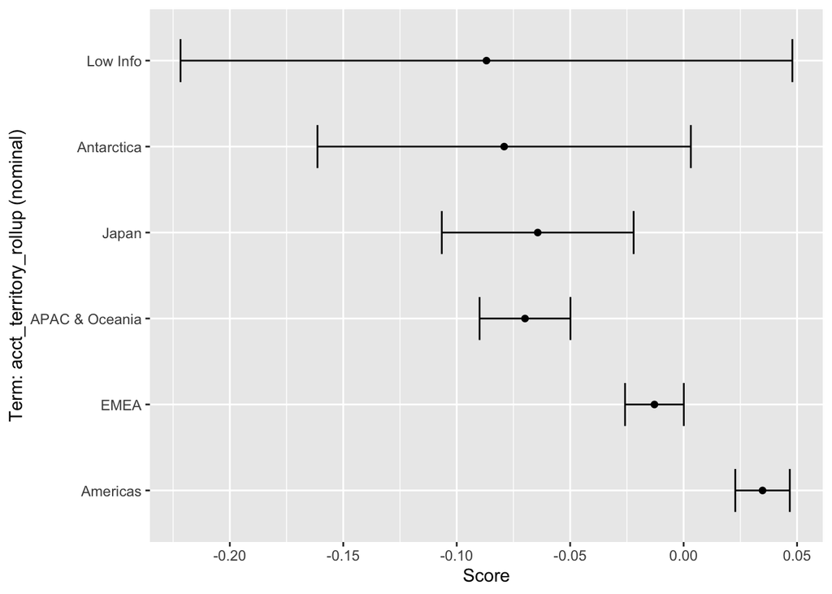

```r
# Main-effect shape function for a key feature
plot(mx_ebm, term = "acct_territory_rollup", horizontal = TRUE)
```

```r
# List any detected pairwise interactions
mx_ebm$term_names_[grepl("&", mx_ebm$term_names_)]
```

```
  [1] "acct_primary_site_function & acct_manufacturing_model"
  [2] "acct_primary_site_function & acct_target_industry"
  [3] "acct_primary_site_function & priority"
  [4] "acct_primary_site_function & acct_territory_rollup"
  [5] "acct_primary_site_function & acct_tier_rollup"
  [6] "acct_primary_site_function & solution"
  [7] "acct_primary_site_function & last_tactic_campaign_channel"
  [8] "acct_primary_site_function & qal_cohort_date"
  [9] "acct_primary_site_function & mfg_lowinfo"
 [10] "acct_primary_site_function & title_lowinfo"
 [11] "acct_primary_site_function & quality"
 [12] "acct_primary_site_function & director"
 [13] "acct_primary_site_function & specialist"
 [14] "acct_primary_site_function & president"
 [15] "acct_primary_site_function & analyst"
```

[output cut: 363 more lines]

### Interpretation of EBM Global Explanation

The term importance plot ranks each feature (and interaction term) by its mean absolute contribution to the predicted log-odds of success. Features at the top of the chart have the largest overall influence on whether a lead is predicted as successful or not.

The shape function plot for `acct_territory_rollup` shows exactly how each territory category shifts the prediction — for example, whether Americas-based leads get a positive boost while APAC leads get a negative one. Unlike a logistic regression coefficient (which gives a single number), the EBM shape function can show nonlinear and non-monotonic relationships.

The listed pairwise interactions reveal which feature combinations the model found to be jointly predictive beyond their individual effects. These interactions can surface insights that single-variable analyses miss — for instance, a specific industry × territory combination that converts unusually well.

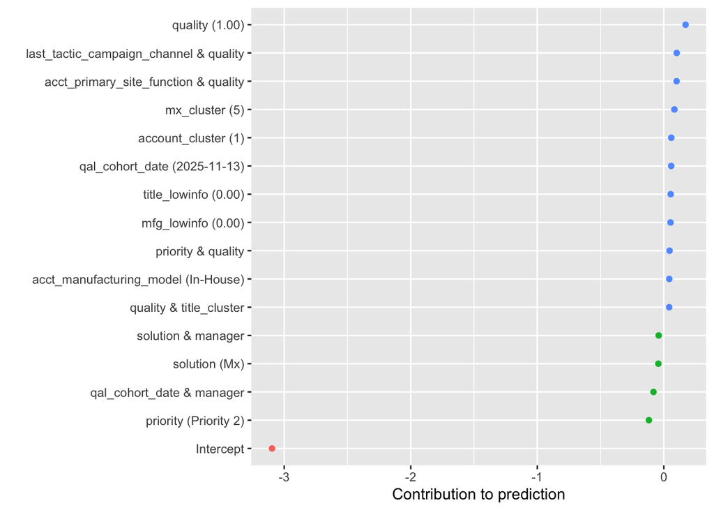

```r
# Local explanation for a single test-set lead
newx <- subset(ebm_test[1L, ], select = -next_stage_target)
newy <- ebm_test$next_stage_target[1L]
plot(mx_ebm, local = TRUE, X = newx, y = newy)
```

### Interpretation of EBM Local Explanation

The local explanation waterfall plot decomposes the prediction for a single lead into the contributions from each feature. Starting from the intercept (the baseline log-odds of success), each bar shows how much a specific feature pushes the prediction up (toward Successful) or down (toward Not Successful).

This is especially useful for the business team because it can answer questions like: *“Why did the model score this particular lead highly?”* or *“What would need to change about this lead for it to be predicted as successful?”* Each local explanation is fully faithful to the model — it is not an approximation — because EBMs are additive by design.

```r
# Save the fitted EBM model as a Python pickle
# (EBM models use reticulate and cannot be saved with saveRDS)
reticulate::py_save_object(mx_ebm, filename = "data/mx_ebm.pkl")


colnames(predict(mx_ebm, newdata = ebm_test[1:3, ]))
```

```
[1] "Not Successful" "Successful"
```

## More EBM Plots

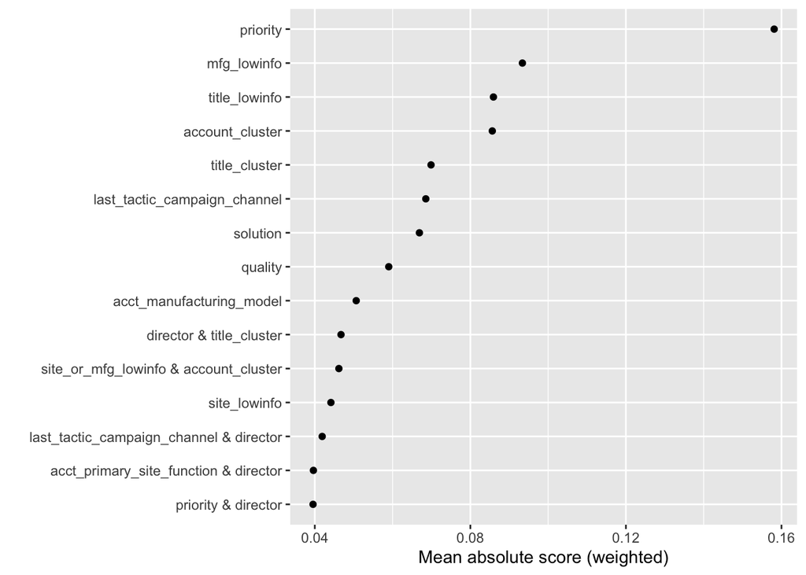

```r
#
plot(mx_ebm, n_terms = 15)   # global feature importance
```

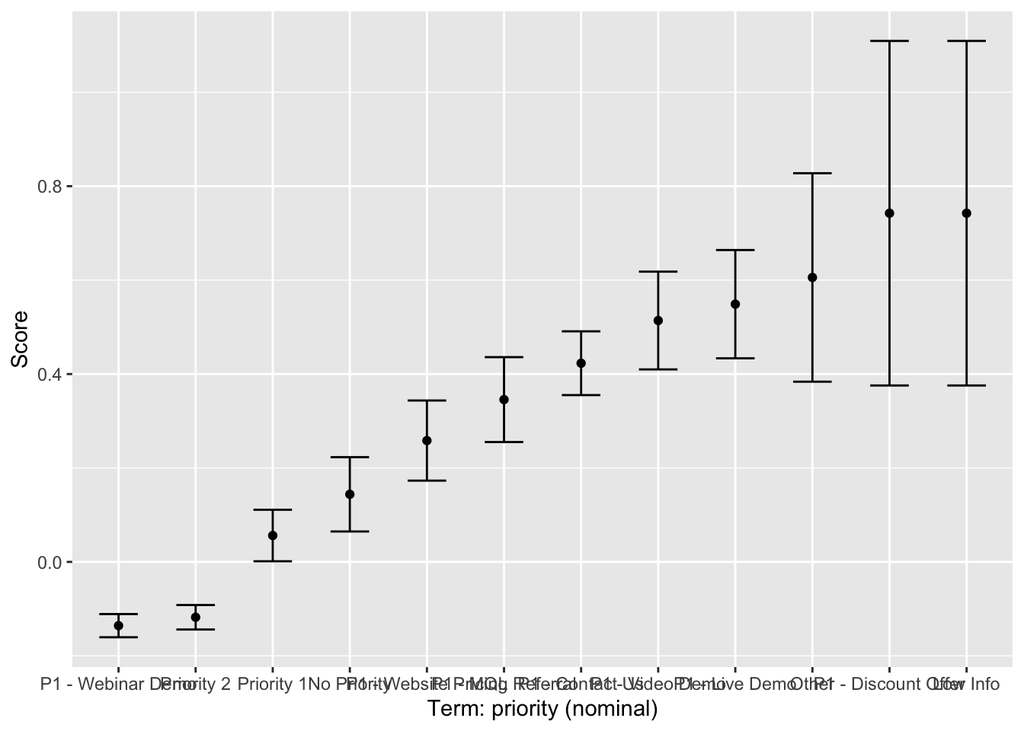

```r
#inspect individual shape functions for your key variables
plot(mx_ebm, term = "priority")
```

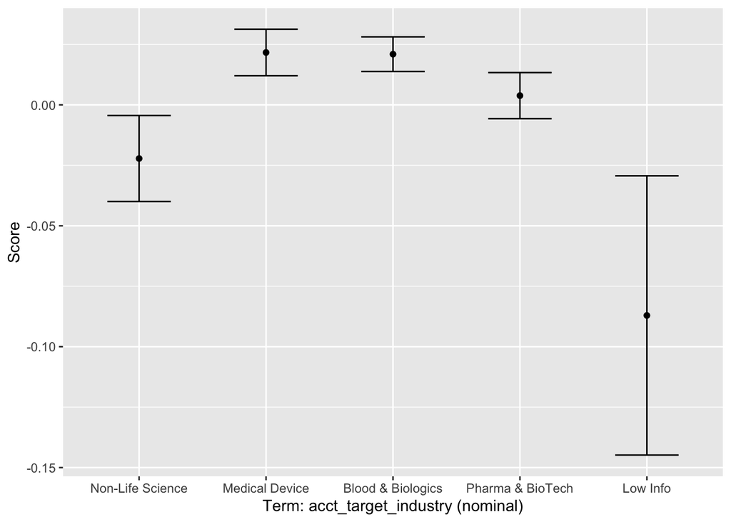

```r
plot(mx_ebm, term = "acct_target_industry")
```

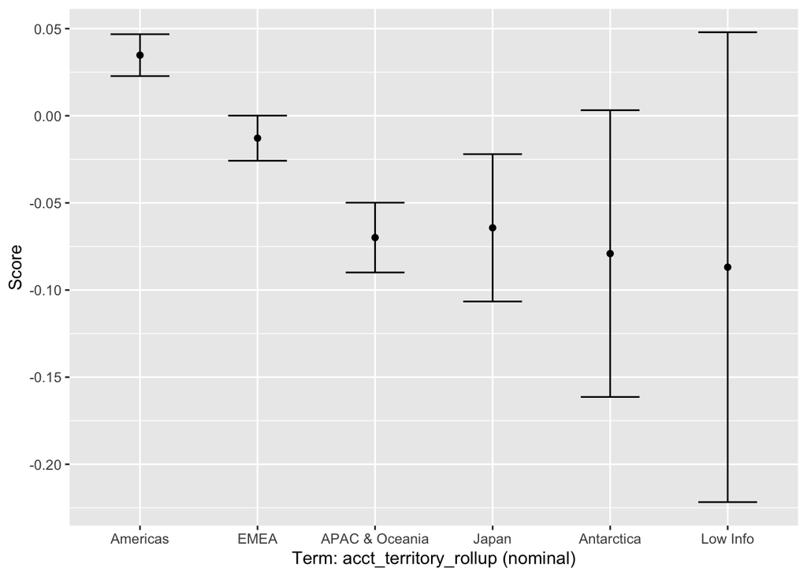

```r
plot(mx_ebm, term = "acct_territory_rollup")
```

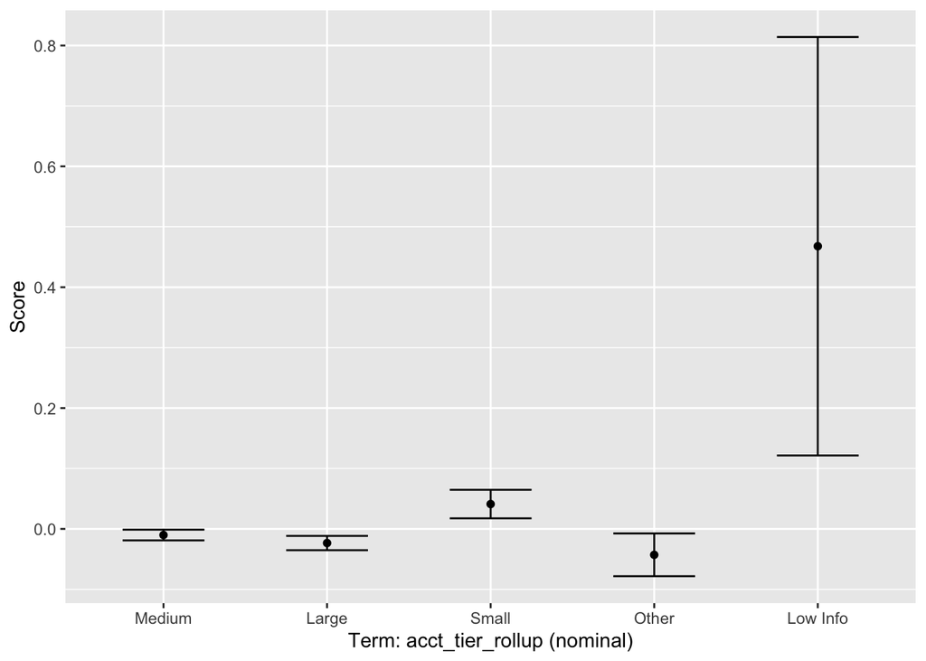

```r
plot(mx_ebm, term = "acct_tier_rollup")
```

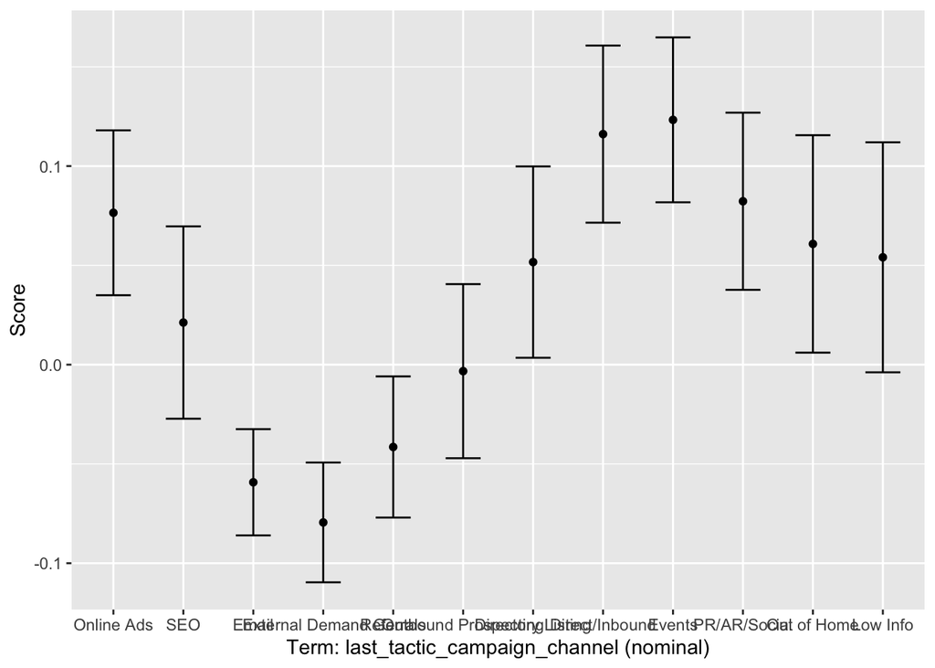

```r
plot(mx_ebm, term = "last_tactic_campaign_channel")
```

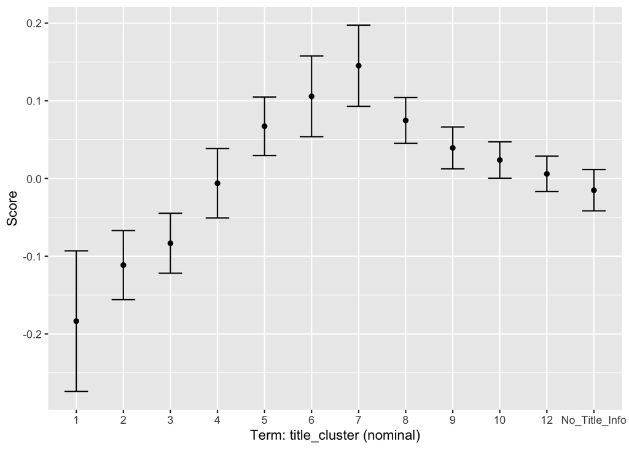

```r
plot(mx_ebm, term = "title_cluster")
```

### Job Title Cluster Labels

Used to clarify the title clusters for EBM shape function - title cluster plot.

```r
#title cluster labels
readRDS("data/leads_cleaned_final.rds") %>%
  left_join(cluster_labels, by = "qal_id") %>%
  filter(solution_rollup == "Mx") %>%
  filter(!is.na(title_cluster)) %>%
  select(contact_lead_title, title_cluster) %>%
  count(title_cluster, contact_lead_title) %>%
  group_by(title_cluster) %>%
  slice_max(n, n = 5) %>%
  arrange(title_cluster) %>%
  print(n = Inf)
```

```
# A tibble: 66 × 3
# Groups:   title_cluster [11]
   title_cluster contact_lead_title                                n
   <fct>         <chr>                                         <int>
 1 1             director quality assurance                       16
 2 1             director quality                                 11
 3 1             associate director quality                        5
 4 1             associate director quality assurance              5
 5 1             quality specialist                                5
 6 2             director operations                              52
 7 2             director                                         35
 8 2             director manufacturing                           21
 9 2             managing director                                21
10 2             director engineering                             11
11 3             consultant                                       13
```

[output cut: 55 more lines]

**Plot 1 - Priority** This is the most important feature with a mean absolute score of ~.16.

**Plot 2 - Priority Shape Function** P1 - Webinar Demo and Priority 2 are the most negative, meaning the model penalizes these leads below baseline. Leads who register for a webinar that become Mx leads don’t convert well. This could be because webinar attract a broader and less ready to by audience. P1 - Contact Us, P1 - Video Demo, and P1 - Live Demo are positive, ~.4-.5. P1 - Discount Offer and Low Info have the highest scores, ~.75-.78 but with wide confidence intervals, meaning few examples of these leads.

**Plot 3 - Industry Shape Function** Scores are relatively tight and close to zero, meaning that industry alone is not a strong indicator once other variables are controlled for. Medical Device and Blood & Biologics are slightly positive, ~.02. Low Info being the most negative at ~-.09, having an unknown industry for a lead is a bag signal of conversion. Compared to the raw data conversion rates, the model is telling us that industry matters less once we account for other features in the model.

**Plot 4 - Territory Shape Function** Americas is the only positive territory, ~.035. Antarctica and Low Info are negative with wide uncertainty. Americas being the only positive score, this is the only territory the model views favorable for Mx conversion.

**Plot 5 - Account Tier Shape Function** Small account tier is slightly positive, ~.035, but Low Info has the highest score of ~.47 and a wide confidence internal. Having no account tier information, the model scores it higher on average but with little observations/cases of Low Info in the data set the estimate is unreliable. Small is the only positive tier, but with modest effects.

**Plot 7 - Job Title Cluster** Cluster 7 has the highest positive score of ~.15. The job titles in this cluster include: founder, director of quality, manager production, manager engineering, plant manager, production manager. These job titles are people who are directly involved in the production and manufacturing processes and closest to the manufacturing floor. They feel the pain of quality and manufacturing directly. This would indicate a strong conversion of Mx product. Cluster 1 is the most negative with a score of ~-.19. This cluster has a wider interval, meaning fewer observations, but consistently bad. The job titles associated with this cluster are: director quality assurance, director quality, associate direction quality, quality specialist. Quality assurance leads may be be the wrong person being contacted for the Mx product.

**Optimal Model** The EBM model having a ROC-AUC of .86, this makes the best model predicting conversion.

## Ideal Customer Profile

Because the EBM was the best performing model, we used the EBM shape function scores of each category to create the ideal customer profile and the customer profile MasterControl should avoid.

```r
#ideal customer profile table

icp_table <- tibble(
  Attribute     = c("Priority", "Industry", "Territory",
                    "Account Tier", "Channel", "Job Title"),
  `Target Profile` = c(
    "P1 – Contact Us, P1 – Video/Live Demo",
    "Medical Device, Blood & Biologics",
    "Americas",
    "Small",
    "Direct/Inbound, Events",
    "Founders, Production/Plant/Engineering Managers"
  ),
  `EBM Score (Target)` = c(
    "+0.40 to +0.50",
    "+0.02",
    "+0.035",
    "+0.035",
    "+0.15",
    "+0.15"
  ),
  `Avoid` = c(
    "P1 – Webinar Demo, Priority 2",
    "Non-Life Science, Unknown",
    "APAC & Oceania, Japan",
    "Large",
    "Email, External Demand Gen",
    "QA Directors, Quality Specialists (Route to QX)"
  ),
  `EBM Score (Avoid)` = c(
    "-0.10 to -0.12",
    "-0.03 to -0.09",
    "-0.07",
    "-0.03",
    "-0.07 to -0.09",
    "-0.19"
  )
)
icp_table
```

```
# A tibble: 6 × 5
  Attribute    `Target Profile`   `EBM Score (Target)` Avoid `EBM Score (Avoid)`
  <chr>        <chr>              <chr>                <chr> <chr>
1 Priority     P1 – Contact Us, … +0.40 to +0.50       P1 –… -0.10 to -0.12
2 Industry     Medical Device, B… +0.02                Non-… -0.03 to -0.09
3 Territory    Americas           +0.035               APAC… -0.07
4 Account Tier Small              +0.035               Large -0.03
5 Channel      Direct/Inbound, E… +0.15                Emai… -0.07 to -0.09
6 Job Title    Founders, Product… +0.15                QA D… -0.19
```

## Raw Data - Conversion Rates Per Category

```r
#load raw data and filter mx leads only
mx_raw <-  read.csv("data/Mastercontrol QAL Performance.csv") %>%
  filter(solution_rollup == "Mx") %>%
  mutate(converted = next_stage__c %in% c("SQL", "SQO", "Won"))

#industry conversion rates
mx_raw %>%
  group_by(acct.target.industry) %>%
  summarise(conversion_rate = mean(converted), n = n()) %>%
  arrange(desc(conversion_rate))
```

```
# A tibble: 6 × 3
  acct.target.industry conversion_rate     n
  <chr>                          <dbl> <int>
1 ""                            0.4       10
2 "Blood & Biologics"           0.170     94
3 "Medical Device"              0.160    937
4 "Pharma & BioTech"            0.120   2008
5 "Non-Life Science"            0.110   1065
6 "Unknown"                     0.0312    64
```

```r
#manufacturing model conversion rates
mx_raw %>%
  group_by(acct.manufacturing.model) %>%
  summarise(conversion_rate = mean(converted), n = n()) %>%
  arrange(desc(conversion_rate))
```

```
# A tibble: 20 × 3
   acct.manufacturing.model             conversion_rate     n
   <chr>                                          <dbl> <int>
 1 "503A"                                        0.6       10
 2 "Consumer Packaged Goods"                     0.270     37
 3 "503B"                                        0.222     18
 4 "Original Equipment Manufacturing"            0.220    127
 5 "Testing Laboratory"                          0.2       15
 6 ""                                            0.190     21
 7 "CMO"                                         0.190    326
 8 "Hospital Investigational Drug Unit"          0.172     29
 9 "CDMO"                                        0.147    490
10 "In-House"                                    0.137   1895
11 "CPO"                                         0.118     17
12 "Outsources Manufacturing"                    0.108     37
13 "Software / Technology Development"           0.0909    99
14 "CRO"                                         0.0822    73
15 "Distribution / Wholesale"                    0.0722    97
16 "Services / Consulting"                       0.0638   329
17 "Not Enough Info Found"                       0.0501   479
18 "Research Institute"                          0.0411    73
19 "Cold Chain Warehousing"                      0          4
20 "Formulation / Fill-Finish"                   0          2
```

```r
#priority converesion rates
mx_raw %>%
  group_by(Priority) %>%
  summarise(conversion_rate = mean(converted), n = n()) %>%
  arrange(desc(conversion_rate))
```

```
# A tibble: 11 × 3
   Priority             conversion_rate     n
   <chr>                          <dbl> <int>
 1 P1 - Website Pricing          0.6       20
 2 P1 - Discount Offer           0.5        2
 3 Other                         0.4        5
 4 P1 - Video Demo               0.311    122
 5 P1 - Contact Us               0.299    331
 6 P1 - MQL Referral             0.286      7
 7 Priority 1                    0.263    729
 8 P1 - Live Demo                0.209    115
 9 No Priority                   0.190    116
10 P1 - Webinar Demo             0.0962   416
11 Priority 2                    0.0419  2315
```

```r
#territory conversion rates
mx_raw %>%
  group_by(acct.territory.rollup) %>%
  summarise(conversion_rate = mean(converted), n = n()) %>%
  arrange(desc(conversion_rate))
```

```
# A tibble: 7 × 3
  acct.territory.rollup conversion_rate     n
  <chr>                           <dbl> <int>
1 ""                             0.161     31
2 "Americas"                     0.147   2206
3 "EMEA"                         0.118   1014
4 "Japan"                        0.118     51
5 "APAC & Oceania"               0.0848   873
6 "Antarctica"                   0          1
7 "Unknown"                      0          2
```

```r
#account tier conversion rates
mx_raw %>%
  group_by(acct.tier.rollup) %>%
  summarise(conversion_rate = mean(converted), n = n()) %>%
  arrange(desc(conversion_rate))
```

```
# A tibble: 5 × 3
  acct.tier.rollup conversion_rate     n
  <chr>                      <dbl> <int>
1 ""                        0.4       10
2 "Small"                   0.163    918
3 "Medium"                  0.128   2563
4 "Large"                   0.072    625
5 "Other"                   0.0484    62
```

```r
#campaign channel conversion rates
mx_raw %>%
  group_by(last.tactic.campaign.channel) %>%
  summarise(conversion_rate = mean(converted), n = n()) %>%
  arrange(desc(conversion_rate))
```

```
# A tibble: 12 × 3
   last.tactic.campaign.channel conversion_rate     n
   <chr>                                  <dbl> <int>
 1 SEO                                   0.268    463
 2 Direct/Inbound                        0.242    331
 3 Events                                0.204    201
 4 Referrals                             0.2       20
 5 Directory Listing                     0.189    106
 6 Online Ads                            0.182    797
 7 Outbound Prospecting                  0.148    115
 8 MISSING/BLANK                         0.132     38
 9 Email                                 0.0582  1134
10 External Demand Gen                   0.0285   949
11 Out of Home                           0          3
12 PR/AR/Social                          0         21
```

## Hypothetical Scenarios

In this section, we demonstrate the practical utility of the EBM model by scoring a single, fully specified hypothetical lead – a prospect that the sales team might realistically reach out to. Rather than pulling an anonymous row from the test set, we construct a lead from scratch using field values that are plausible for a strong Mx prospect, and then ask the model: *what is the probability this lead converts?*

### Hypothetical Scenario 1 - Sarah

```r
#hypothetical lead
set.seed(123)
template_row <- ebm_test[sample(nrow(ebm_test), 1), ]

#building the lead row
sarah_lead <- template_row %>%
  mutate(
    #account characteristics
    acct_target_industry        = "Medical Device",
    acct_manufacturing_model    = "In-House",
    acct_territory_rollup       = "Americas",
    acct_tier_rollup            = "Small",
    acct_primary_site_function  = "Implantable devices",
    #engagement and campaign signals
    priority                    = "P1 - Contact Us",
    last_tactic_campaign_channel = "SEO",
    title_cluster               = 7
  )

#predict
sarah_probs <- predict(mx_ebm, newdata = sarah_lead)

#probabilities
sarah_p_success     <- round(sarah_probs[1, 2], 4)   # P(Successful)
sarah_p_not_success <- round(sarah_probs[1, 1], 4)   # P(Not Successful)

#return details
tibble(
  Attribute = c("Industry", "Mfg Model", "Territory", "Tier",
                "Priority", "Channel", "Title Cluster"),
  Value     = c(
    sarah_lead$acct_target_industry,
    sarah_lead$acct_manufacturing_model,
    sarah_lead$acct_territory_rollup,
    sarah_lead$acct_tier_rollup,
    sarah_lead$priority,
    sarah_lead$last_tactic_campaign_channel,
    as.character(sarah_lead$title_cluster)
  )
)
```

```
# A tibble: 7 × 2
  Attribute     Value
  <chr>         <chr>
1 Industry      Medical Device
2 Mfg Model     In-House
3 Territory     Americas
4 Tier          Small
5 Priority      P1 - Contact Us
6 Channel       SEO
7 Title Cluster 7
```

```r
#compare to baseline mx conversion rate
baseline_mx_rate <- mean(
  ebm_test$next_stage_target == "Successful",
  na.rm = TRUE
)

#calculate lift over baseline conversion rate
lift_over_baseline <- sarah_p_success / baseline_mx_rate

#sarah prediction summary table
tibble(
  Metric = c("P(Successful)", "P(Not Successful)",
             "Baseline MX Conversion Rate", "Lift over Baseline"),
  Value  = c(
    sprintf("%.1f %%", sarah_p_success     * 100),
    sprintf("%.1f %%", sarah_p_not_success * 100),
    sprintf("%.1f %%", baseline_mx_rate    * 100),
    sprintf("%.2fx",   sarah_p_success / baseline_mx_rate)
  )
)
```

```
# A tibble: 4 × 2
  Metric                      Value
  <chr>                       <chr>
1 P(Successful)               97.2 %
2 P(Not Successful)           2.8 %
3 Baseline MX Conversion Rate 12.9 %
4 Lift over Baseline          7.52x
```

### Interpretation of Hypothetical Scenario - Sarah

The model returns a **predicted conversion probability of 97.2 %**, compared to the baseline Mx conversion rate of approximately **12.9 %**. This represents a lift of roughly **7.5× over the average Mx lead**.

From a business perspective, a lead like Sarah is precisely the type of profile that MasterControl’s sales team should prioritize for Mx outreach. She represents an ideal intersection of high engagement, the right product fit, and favorable account characteristics leading to canidates similar to her, high converting to the Mx product.

### Hypothetical Scenario 2 - David

We ran a second hypothetical scenario in the model that is a lead with different job demographics to show contrast between two different converting leads.

```r
#hypothetical scenario - david
set.seed(42)
template_row_low <- ebm_test[sample(nrow(ebm_test), 1), ]

david_lead <- template_row_low %>%
  mutate(
    #account characteristics
    acct_target_industry        = "Unknown",
    acct_manufacturing_model    = "Services / Consulting",
    acct_territory_rollup       = "APAC & Oceania",
    acct_tier_rollup            = "Large",
    acct_primary_site_function  = "Non-manufacturing organization",

    #engagement and campaign signals
    priority                     = "No Priority",
    last_tactic_campaign_channel = "Online Ads",
    title_cluster               = 1
  )

#score with ebm
david_probs <- predict(mx_ebm, newdata = david_lead)

david_p_success     <- round(david_probs[1, 2], 4)
david_p_not_success <- round(david_probs[1, 1], 4)

#return details
tibble(
  Attribute = c("Industry", "Mfg Model", "Territory", "Tier",
                "Priority", "Channel", "Title Cluster"),
  Value     = c(
    david_lead$acct_target_industry,
    david_lead$acct_manufacturing_model,
    david_lead$acct_territory_rollup,
    david_lead$acct_tier_rollup,
    david_lead$priority,
    david_lead$last_tactic_campaign_channel,
    as.character(david_lead$title_cluster)
  )
)
```

```
# A tibble: 7 × 2
  Attribute     Value
  <chr>         <chr>
1 Industry      Unknown
2 Mfg Model     Services / Consulting
3 Territory     APAC & Oceania
4 Tier          Large
5 Priority      No Priority
6 Channel       Online Ads
7 Title Cluster 1
```

```r
#david prediction summary table
tibble(
  Metric = c("P(Successful)", "P(Not Successful)",
             "Baseline MX Conversion Rate", "Lift over Baseline"),
  Value  = c(
    sprintf("%.1f %%", david_p_success     * 100),
    sprintf("%.1f %%", david_p_not_success * 100),
    sprintf("%.1f %%", baseline_mx_rate    * 100),
    sprintf("%.2fx",   david_p_success / baseline_mx_rate)
  )
)
```

```
# A tibble: 4 × 2
  Metric                      Value
  <chr>                       <chr>
1 P(Successful)               2.5 %
2 P(Not Successful)           97.5 %
3 Baseline MX Conversion Rate 12.9 %
4 Lift over Baseline          0.19x
```

### Interpretation of Hypothetical Scenario 2 - David

To show contract with the high performing lead, we added a lead with a complete opposite ideal lead profile and ran it through the model to get conversion rate prediction for the lead.

The model returns a **predicted conversion probability of 2.5 %**, compared to the baseline Mx conversion rate of approximately **12.9 %**. This represents a lift of roughly **0.2× the average Mx lead**, meaning the model views David as a significantly below-average prospect/lead.

From a business perspective, David represents the type of profile that MasterControl’s sales team should deprioritize for Mx outreach. His combination of low engagement signals, an unidentifiable account, a non-manufacturing business model, and an unfavorable territory makes him a low converting candidate. Rather than direct sales outreach, leads matching David’s profile may be better served through lower-cost nurture campaigns until a stronger engagement signal develops.

## Synthetic Cost Table Analysis

In this section, we build a cost-benefit table that evaluates the economic value of deploying the EBM model at different decision thresholds. The core idea is: the model generates a probability score for each lead, and the sales team decides which leads to pursue based on a probability cutoff. A higher cutoff means chasing only the most confident predictions (fewer outreach touches, but more targeted); a lower cutoff means casting a wider net (more outreach, but more false positives).

By estimating revenue and cost per threshold, we can identify the estimated optimal operating point for the business.

**Key Values:**

| Parameter | Value | Source |
| --- | --- | --- |
| Average Mx product revenue (proxy) | $70,000 | Provided (Qx product cost) |
| Estimated cost per QAL outreach | $100-$1000 | Sales rep time + campaign cost |
| Probability Thresholds | .1-.7 | Using EBM Predictions |

```r
#assumptions
revenue_per_conversion <- 70000  # average MX deal value ($70K proxy from Qx)
outreach_costs         <- seq(100, 1000, by = 100)  # $100 to $1,000 in $100 increments

#candidate decision thresholds on P(Successful)
thresholds <- seq(0.10, 0.7, by = 0.05)

#utilizing EBM predictions on held-out test set
df_cost <- tibble(
  truth     = ebm_test$next_stage_target,
  p_success = predict(mx_ebm, newdata = ebm_test)[, 2L]
)

#function: one row of economics per threshold + cost combination
cost_row <- function(t, cost_per_outreach) {
  #pursue leads with predicted success probability at or above t
  pursue <- df_cost$p_success >= t

  pursue_rate <- mean(pursue)

  #expected counts per 1,000 leads
  pursued_1000       <- 1000 * pursue_rate
  conversions_1000   <- 1000 * mean(pursue & df_cost$truth == "Successful")
  no_conversion_1000 <- 1000 * mean(pursue & df_cost$truth == "Not Successful")

  #economics per 1,000 leads
  expected_revenue_1000 <- conversions_1000 * revenue_per_conversion
  expected_cost_1000    <- pursued_1000     * cost_per_outreach
  net_value_1000        <- expected_revenue_1000 - expected_cost_1000

  tibble(
    cost_per_outreach          = cost_per_outreach,
    p_success_threshold        = t,
    pursued_per_1000           = round(pursued_1000,         1),
    conversions_per_1000       = round(conversions_1000,     1),
    no_conversion_per_1000     = round(no_conversion_1000,   1),
    expected_revenue_1000      = round(expected_revenue_1000, 0),
    expected_cost_1000         = round(expected_cost_1000,    0),
    net_value_1000             = round(net_value_1000,        0)
  )
}

#build cost table across all threshold + cost combinations
ebm_cost_table <- expand.grid(
  t                = thresholds,
  cost_per_outreach = outreach_costs
) |>
  purrr::pmap_dfr(~ cost_row(..1, ..2)) |>
  arrange(cost_per_outreach, p_success_threshold)

#show full table
ebm_cost_table
```

```
# A tibble: 130 × 8
   cost_per_outreach p_success_threshold pursued_per_1000 conversions_per_1000
               <dbl>               <dbl>            <dbl>                <dbl>
 1               100                0.1             300.                 105.
 2               100                0.15            238.                  98.9
 3               100                0.2             197.                  91.6
 4               100                0.25            157                   80.9
 5               100                0.3             133.                  75.2
 6               100                0.35            103                   63.8
 7               100                0.4              85.9                 58.1
 8               100                0.45             72                   53.1
 9               100                0.5              58.1                 49.1
10               100                0.55             49.9                 42.5
# ℹ 120 more rows
# ℹ 4 more variables: no_conversion_per_1000 <dbl>,
#   expected_revenue_1000 <dbl>, expected_cost_1000 <dbl>, net_value_1000 <dbl>
```

```r
#best threshold per outreach cost level
best_threshold_by_cost <- ebm_cost_table |>
  group_by(cost_per_outreach) |>
  slice_max(net_value_1000, n = 1) |>
  ungroup() |>
  arrange(cost_per_outreach)

best_threshold_by_cost
```

```
# A tibble: 10 × 8
   cost_per_outreach p_success_threshold pursued_per_1000 conversions_per_1000
               <dbl>               <dbl>            <dbl>                <dbl>
 1               100                 0.1             300.                 105.
 2               200                 0.1             300.                 105.
 3               300                 0.1             300.                 105.
 4               400                 0.1             300.                 105.
 5               500                 0.1             300.                 105.
 6               600                 0.1             300.                 105.
 7               700                 0.1             300.                 105.
 8               800                 0.1             300.                 105.
 9               900                 0.1             300.                 105.
10              1000                 0.1             300.                 105.
# ℹ 4 more variables: no_conversion_per_1000 <dbl>,
#   expected_revenue_1000 <dbl>, expected_cost_1000 <dbl>, net_value_1000 <dbl>
```

## Cost Table Interpretation

- **Cost Per Outreach**: Cost levels ranging from $100-$1000. The cost can be sales rep time + campaign cost. Dependent on how MasterControl defines their cost for employee and outreach methods.
- **Probability Success Threshold**: Probability of success across different thresholds ranging from .1-.7 probability.
- **Pursued Per 1000**: Pursue leads with predicted success probability at or above t.
- **Conversions Per 1000**: Leads that convert to Mx product per 1000 leads.
- **No Conversions Per 1000**: Leads that did not conver to Mx product per 1000 leads.
- **Expected Revenue Per 1000**: Revenue gained per 1000 leads at each cost and probability thresholds (total contract value * conversions per 1000)
- **Expected Cost Per 1000**: Expected cost (pursed per 1000 * cost per outreach)
- **Net Value Per 1000**: The net value gained per 1000 leads (expected revenue per 1000 - expected cost per 1000)

The best threshold table returns the max **Net Value Per 1000** from each **Cost Per Outreach** level and **Probability of Success** threshold. The optimal probability threshold per this table is .1 probability of success. Lowering the probability threshold allows more false positives to be contacted, those that are predicted as successful, but are not successful. This is essentially saying “pursue as many leads a possible because even with a small hit rate generates enormous revenue”.

At a .1 probability threshold, if approximately 104.7 conversions per 1,000 leads pursued and each conversion is on average $70,000 average total Mx contract value over a 2-4 year contract term. Then $70,000 * 104.7 = ~$7.3 million in revenue that reflects the full lifetime value of each converted lead. Even at a $1,000 outreach cost * 300 leads pursued = $300,000 in cost. The net value is still ~$7 million for the lifetime value. The cost of $300,000 is almost irrelevant against a $70,000 contract deal.

# Team Contributions

- Gaby: Data setup, Logistic Regression (baseline model), Decision Tree, interpretations
- Joel: Random Forest, XGBoost models, interpretations
- Josh: EBM Model and interpretations
- Corinn: Extra EBM shape function plots, ideal customer profile, raw data conversion rates, hypothetical scenarios, cost table, interpretations